# Parte 1 - Modulacion de amplitud

La modulación de amplitud es el proceso de cambiar la amplitud de una señal portadora de frecuencia relativamente alta, en proporcion con el valor instantaneo de la señal modulante de frecuencia relativamente mas baja.

## Características:

- Poco costosa la modulación y demodulación
- Baja calidad
- Usada para audio y video

## Modulador:

Es un dispositivo no lineal con dos entradas (señal de portadora y de mensaje) y una salida (señal modulada)

## Tipos de modulacione de amplitud

- BLU (banda lateral unica) en ingles SSB (single side band)
- DBL-Ps (doble banda lateral con portadora suprimida)
- AM (amplitud modulada)
- BLV (Banda lateral vestigial)

# Transmision

$y(t)=f(t).cos(\omega_c .t+\phi(t))$

## aplicando la trasnformada de Fourier

$Y(\omega)=\frac{1}{2} F(\omega-\omega_c)+\frac{1}{2} F(\omega+\omega_c)$

[figure not shown]

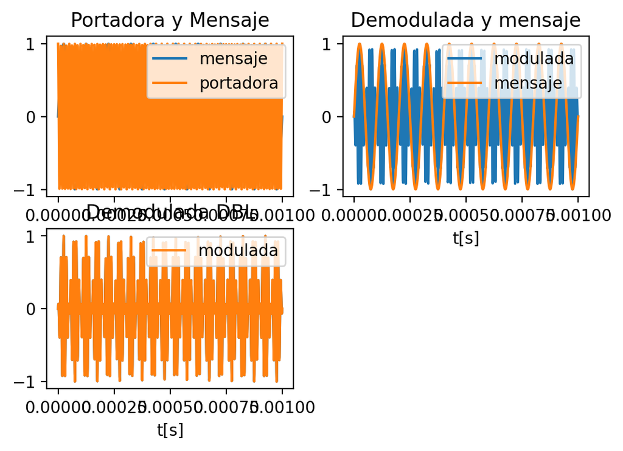

```python
import numpy as np
import matplotlib.pyplot as plt
N=1000
t=np.linspace(0,1e-3,N) # un eje de tiempo de 1ms muestreado a 1us genera 1000 muestras
ts=t[1] # el primer diferencia entre la posicion "0" del vector de tiempo y la "1" es el tiempo de muestreo
fs=1/ts # la frecuencia de muestreo es la inversa del tiempo de muestreo
fmsj=10000 # frecuencia del mensaje Hz
fc=80000 # frecuencia de la portadora Hz

msj=np.sin(2*np.pi*fmsj*t)
carrier=np.cos(2*np.pi*fc*t)
plt.figure(dpi=200)
plt.subplot(2,2,1)

plt.plot(t,msj,label="mensaje")
plt.plot(t,carrier,label="portadora")
plt.legend(loc='upper right')
plt.xlabel("t[s]")
plt.ticklabel_format(style="sci")
plt.title("Portadora y Mensaje")


######################
### la modulación ####
######################
def M_DBL(a,b):  # es muy sencillo...solamente es el producto, que en la practica se hace con un mezclador aca con numeros
    return a*b

DBL= M_DBL(msj,carrier)
plt.subplot(2,2,2)
plt.plot(t,DBL,label="modulada")
plt.plot(t,msj,label="mensaje")
plt.legend(loc='upper right')
plt.xlabel("t[s]")
plt.title("Demodulada y mensaje")
plt.ticklabel_format(style="sci")


plt.subplot(2,2,3)
plt.plot(t,DBL)
plt.plot(t,DBL,label="modulada")
plt.legend(loc='upper right')
plt.xlabel("t[s]")
plt.title("Demodulada DBL")
plt.ticklabel_format(style="sci")
```

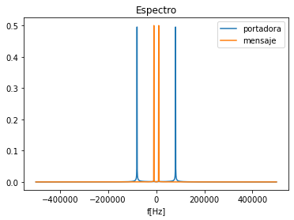

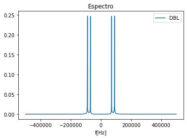

```python
# en el espectro
fcia=np.linspace(-fs/2,fs/2,N)
Fcarrier=np.abs(np.fft.fftshift(np.fft.fft(carrier)))/N
Fmsj=np.abs(np.fft.fftshift(np.fft.fft(msj)))/N
plt.figure()
plt.plot(fcia,Fcarrier,label="portadora")
plt.plot(fcia,Fmsj,label="mensaje")
plt.legend(loc='upper right')
plt.xlabel("f[Hz]")
plt.title("Espectro")


FDBL=np.abs(np.fft.fftshift(np.fft.fft(DBL)))/N
plt.figure()
plt.plot(fcia,FDBL,label="DBL")
plt.legend(loc='upper right')
plt.xlabel("f[Hz]")
plt.title("Espectro")
```

# Recepción

La demodulación, es decir, la recuperación de la información de la señal original requiere nuevamente otra translacion del espectro.

$f(t).cos(\omega_c.t) . cos(\omega_c.t) = f(t).cos(\omega_c .t)^2$

reemplazando en el segundo termino

$f(t).cos(\omega_c.t) . cos(\omega_c.t) = \frac{1}{2}.f(t)+\frac{1}{2}.f(t).cos(2.\omega_c .t)$

aplicando Fourier a ambos lados

$F\{f(t).cos(\omega_c.t) . cos(\omega_c.t)\}=F\{\frac{1}{2}.f(t)+\frac{1}{2}.f(t).cos(2.\omega_c .t)\}$

[figure not shown]

Lo que obtenemos a la salida del mezclado que realiza la multiplicación por $cos(\omega_c.t)$

$F\{f(t).cos(\omega_c.t) . cos(\Omega_c.t)\}=\frac{1}{2}.F(\omega)+\frac{1}{4}.F(\omega - 2.\omega_c)+\frac{1}{4}.F(\omega + 2.\omega_c)$

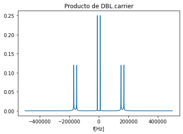

```python
DBL_rx=DBL*carrier

FDBL_rx=np.abs(np.fft.fftshift(np.fft.fft(DBL_rx)))/N
plt.figure()
plt.plot(fcia,FDBL_rx)
plt.xlabel("f[Hz]")
plt.title("Producto de DBL.carrier")
```

Nos queda la tarea de eliminar la parte alta del espectro implementando un filtro pasa bajos.

scipy.signal.firwin(numtaps, cutoff, width=None, window='hamming', pass_zero=True, scale=True, nyq=None, fs=None)

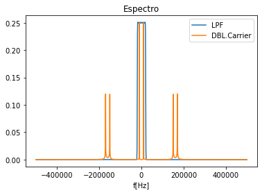

```python
from scipy import signal as dsp
taps=dsp.firwin(N,cutoff=20000,fs=fs)
LPF=np.abs(np.fft.fftshift(np.fft.fft(taps)))/N
plt.figure()
plt.plot(fcia,LPF*(N/4),label="LPF")  ## escale en (N/4) asi el filtro que sobre la es espectro como en el libro
plt.plot(fcia,FDBL_rx,label="DBL.Carrier")
plt.legend(loc='upper right')
plt.xlabel("f[Hz]")
plt.title("Espectro")
```

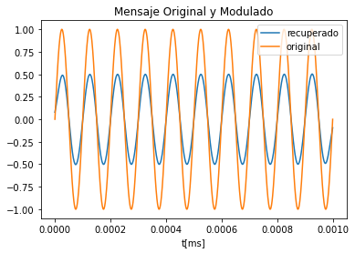

```python
## Tranca... aca solamente hay que hacer el proceso de filtrado, convolucionando la respuesta del
## filtro con la señal de salida del mezclador

def DEMOD_DBL(a,b,taps):
    c=a*b
    return np.convolve(c,taps,'same')

Rx=DEMOD_DBL(DBL,carrier,taps)

Rx=np.convolve(taps,DBL_rx,'same')
plt.plot(t,Rx,label="recuperado")
plt.plot(t,msj,label="original")
plt.legend(loc='upper right')
plt.title("Mensaje Original y Modulado")
plt.xlabel("t[ms]")
```

# EJERCICIO 1

- como mensaje utilizar una señal cuadrada y que a partir del 3er armonico no entre en el filtro pasabajos
- simular y generar las imagenes correspondientes a la señal original y recuperada despues de la demodulación

Hasta aca parece todo facil, pero quedan muchas cosas interesantes para analizar.

Por ejemplo:

- que pasa con la fase relativa de la portadora durante la modulación???

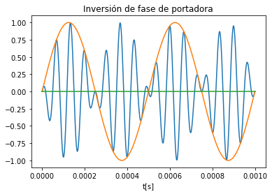

```python
fmsj=2000 # frecuencia del mensaje Hz
fc=15000 # frecuencia de la portadora Hz

msj=np.sin(2*np.pi*fmsj*t)
carrier=np.cos(2*np.pi*fc*t)

plt.plot(t,M_DBL(msj,carrier),t,msj,t,np.zeros(N))
plt.xlabel("t[s]")
plt.title("Inversión de fase de portadora")
```

La fase de la portadora cambia 180 grados cuando el mensaje cambia de signo. Es decir que si pudieramos seguir la fase de la portadora poriamos saber que signo tiene el mensaje. Lo otro muy importante es que para recuperar el mensaje no alcanza solamente con recuperar la envolvente de la portadora.

- Que pasa si el receptor no multiplica exactamente pot la misma señal cos(wc.t) que hizo el Tx en el proceso de demodulacion??

si $\phi(t)$ es una señal modulada en DBL con el $cos(\omega_c .t)$ y queremos recuperar el mensaje en el receptor con una señal $cos((\omega_c + \Delta\omega) .t + \Delta\theta)$

Se puede demostras que la salida del demodulador queda

$Rx=\frac{1}{2}.f(t).cos(\Delta\omega_t + \Delta\phi)$

Es decir que la salida que tendriamos en condiciones normales $\frac{1}{2}.f(t)$ queda multiplicada por $cos(\Delta\omega_t + \Delta\phi)$

Analicemos 2 casos:

1) $\Delta\omega = 0$ y $\Delta\phi = variable$

2) $\Delta\omega = variable$ y $\Delta\phi = 0$

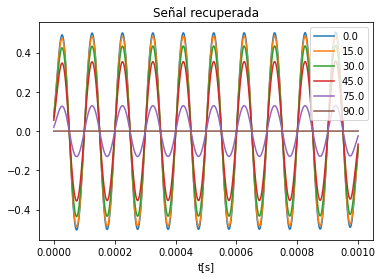

```python
####################################################
### CASO 1 ########################################
###################################################

fmsj=10000 # frecuencia del mensaje Hz
fc=80000 # frecuencia de la portadora Hz

DeltaFase=[np.deg2rad(0),np.deg2rad(15),np.deg2rad(30),np.deg2rad(45),np.deg2rad(75),np.deg2rad(90)]

DBL= M_DBL(np.sin(2*np.pi*fmsj*t),np.cos(2*np.pi*fc*t))

for fase in DeltaFase:
    #print (fase)
    Rx=DEMOD_DBL(DBL,np.cos(2*np.pi*fc*t+fase),taps)
    plt.plot(t,Rx,label=round(np.rad2deg(fase),1))
    plt.legend(loc='upper right')
    plt.title("Señal recuperada")
    plt.xlabel("t[s]")
```

Para el caso 1) donde $\Delta\omega = 0$ y $\Delta\phi = variable$

se observa que un error en la fase se ve reflejada en una atenuacion en la señal recibida.

$Rx=\frac{1}{2}.f(t).cos(\Delta\phi)$

Era de imaginarse, ya que el coseno que simulamos varia entre 1 y 0 modulando la amplitud del mensaje

## EJERCICIO 2

- Que pasa cuando el angulo de desfasaje es 90°
- Simular para diferencias de fase mayor a 90° y menores a 360°.
- Extraer conclusiones.

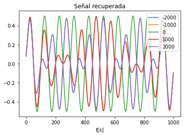

```python
####################################################
### CASO 2 ########################################
###################################################

fmsj=10000 # frecuencia del mensaje Hz
fc=80000 # frecuencia de la portadora Hz

DeltaF=[-2000,-1000,0,1000,2000]

DBL= M_DBL(np.sin(2*np.pi*fmsj*t),np.cos(2*np.pi*fc*t))

for f in DeltaF:
    Rx=DEMOD_DBL(DBL,np.cos((2*np.pi*(fc+f)*t)),taps)
    plt.plot(Rx,label=f)
    plt.legend(loc='upper right')
    plt.title("Señal recuperada")
    plt.xlabel("t[s]")
```

En el caso 2) $\Delta\omega = variable$ y $\Delta\phi = 0$

La salida queda multiplicada por la diferencia de frecuecia

$Rx=\frac{1}{2}.f(t).cos(\Delta\omega_t )$

El sonido es como un batido entre las dos frecuencias

# Modulacion en cuadratura

Del problema analizado de la diferencia de fase entre la portadora suprimida del Tx y la portadora del Rx utilizada para la demodulación un caso curioso se daba para una diferencia de fase de 90°

vamos a hacer lo siguiente

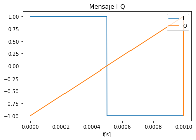

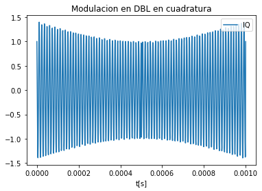

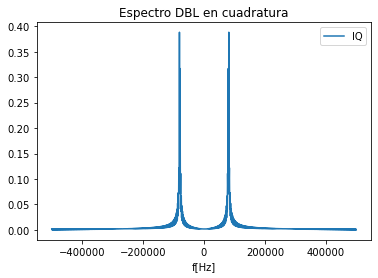

```python
fmsj=1000 # frecuencia del mensaje Hz
fc=80000 # frecuencia de la portadora Hz

Q=dsp.sawtooth(2*np.pi*fmsj*t)
I=dsp.square(2*np.pi*fmsj*t)

plt.figure()
plt.plot(t,I,label="I")
plt.plot(t,Q,label="Q")
plt.legend(loc='upper right')
plt.title("Mensaje I-Q")
plt.xlabel("t[s]")

I_mod=M_DBL(I,np.cos(2*np.pi*fc*t))
Q_mod=M_DBL(Q,np.sin(2*np.pi*fc*t))

QUAD=I_mod+Q_mod
plt.figure()
plt.plot(t,QUAD,label="IQ")
plt.legend(loc='upper right')
plt.title("Modulacion en DBL en cuadratura")
plt.xlabel("t[s]")

FQUAD=np.abs(np.fft.fftshift(np.fft.fft(QUAD)))/N
plt.figure()
plt.plot(fcia,FQUAD,label="IQ")
plt.legend(loc='upper right')
plt.title("Espectro DBL en cuadratura")
plt.xlabel("f[Hz]")
```

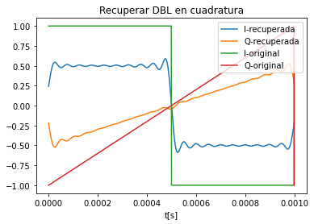

```python
RxI=DEMOD_DBL(QUAD,np.cos(2*np.pi*fc*t),taps)
RxQ=DEMOD_DBL(QUAD,np.sin(2*np.pi*fc*t),taps)

plt.plot(t,RxI,label="I-recuperada")
plt.plot(t,RxQ,label="Q-recuperada")
plt.plot(t,I,label="I-original")
plt.plot(t,Q,label="Q-original")
plt.legend(loc='upper right')
plt.title("Recuperar DBL en cuadratura")
plt.xlabel("t[s]")
```

# EJERCICIO 3

- Hacer una funcion que reciba como parametros mensajeI, mensajeQ, CarrierI, CarrierQ y devuelva una señana modulada en cuadratura.
- Idem funcion para demodular

# AMPLITUD MODULADA

$\Phi_{AM}(t)=f(t).cos(\omega_c . t) + A.cos(\omega_c . t)$

sacando factor común

$\Phi_{AM}(t)=(A+f(t)).cos(\omega_c . t) $

[figure not shown]

Aplicando Fourier

$\Phi_{AM}(\omega)=\frac{1}{2}.[F(\omega-\omega_c)+F(\omega+\omega_c)+A.\delta(\omega+\omega_c)+A.\delta(\omega-\omega_c)] $

## Diagrama fasoria de una señal de AM

[figure not shown]

De la representacoion fasorial se deducen:

## Coeficiente de modulación

Describe la cantidad de cambio de la amplitud de la portadora.

$m=\frac{Em}{Ec}$

Donde:

- Em: es la variacion maxima de la salida
- Ec: es la rension de la portadora sin modulacion

[figure not shown]

Como el proceso de modulacion es simétrico, (las diferencias en amplitud positiva y negativa son iguales)

$Em=\frac{1}{2}(V_{max} - V_{min})$ $Ec=\frac{1}{2}(V_{max} + V_{min})$

Reemplazando

$m=\frac{Em}{Ec}$

$m=\frac{\frac{1}{2}(V_{max} - V_{min})}{\frac{1}{2}(V_{max} + V_{min})}$

$m=\frac{(V_{max} - V_{min})}{(V_{max} + V_{min})}$

El cambio maximo de la amplitud de salida "Em" es igual a la suma faorial de la BLI y la BLS

$E_m=BLI+BLS$

$BLI=BLS = BL$

$\frac{E_m}{2}=\frac{\frac{1}{2}(V_{max}-V{min})}{2}$

La amplitud de las bandas laterales BL = BLI = BLS = $\frac{1}{4}(V_{max}-V{min})$

100% de modulación m=1 hace que Ec = Em

### La expresion de una señana modulada en AM en función de "m" es:

$V_{AM}=[1+m.sen(2.\pi.f_m.t)].sen(2.\pi . f_c .t)$

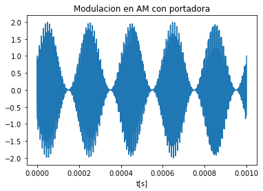

```python
m=1
Ec=1
fmsj=5000
fc=300000 # frecuencia de la portadora Hz

#msj=dsp.sawtooth(2*np.pi*fmsj*t)   # triangular
#msj=dsp.square(2*np.pi*fmsj*t)      # cuadrada

msj=np.sin(2*np.pi*fmsj*t)          # senoidal
carrier=Ec*np.cos(2*np.pi*fc*t)

def M_AM(msj,carrier,m):
    return ((1+m*msj)*carrier)

VAM=M_AM(msj,carrier,m)

plt.plot(t,VAM)
plt.title("Modulacion en AM con portadora")
plt.xlabel("t[s]")
```

## Espectro de AM

Partiendo de

$V_{AM}=[1+m.sen(2.\pi.f_m.t)].Ec.sen(2.\pi . f_c .t)$

$V_{AM}=Ec.sen(2.\pi . f_c .t)+\frac{m.Ec}{2}.sen(2.\pi.(f_c-f_m).t)+\frac{m.Ec}{2}.sen(2.\pi.(f_c+f_m).t)$

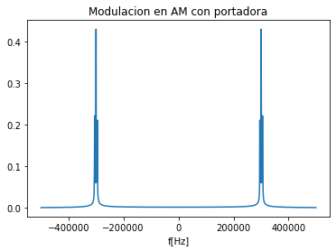

```python
FAM=np.abs(np.fft.fftshift(np.fft.fft(VAM)))/N
plt.figure()
plt.plot(fcia,FAM)
plt.title("Modulacion en AM con portadora")
plt.xlabel("f[Hz]")
```

## Potencia de una señal de AM

La potencia de la portadora $Pc=({\frac{Ec}{\sqrt{2}}})^2 $

Potencia de la banda lateral inferior = banda lateral superior $PBL=({\frac{\frac{m.Ec}{2}}{\sqrt{2}}})^2 $

La potencia total $Pt=Pc+\frac{m^2}{4}.Pc+\frac{m^2}{4}.Pc$

con un indice de modulacion m=1

Pt=Pc.(3/2)

despejando

Pc=Pt.(2/3)

2/3 de la potencia se gasta en la portadora, que no lleva ninguna información. La eficiencia de AM es bajisima, pero muy facil de demodular

```python
Pc=np.mean(carrier*np.conjugate(carrier))  # la expresion de la potencia
print ("La potencia de la portadora es {} W sobre 1ohm ".format(Pc))

Pt=Pc*(1+(m**2)/2)
print ("La potencia total de la señal de AM {} W sobre 1ohm ".format(Pt))
```

```
La potencia de la portadora es 0.5005000000000002 W sobre 1ohm
La potencia total de la señal de AM 0.7507500000000003 W sobre 1ohm
```

```python
Pt=np.mean(VAM*np.conjugate(VAM))  # la expresion de la potencia
print ("La potencia total de la señal de AM {} W sobre 1ohm ".format(Pt))
```

```
La potencia total de la señal de AM 0.7502499999999995 W sobre 1ohm
```

Coincidiendo la expresion de la potencia de AM y la aplicacion de la formula sobre la señal generada

# EJERCICIO 4

implementar un demodulador de AM que reciba una señal modulada en AM, un float con el valor de la frecuencia de portadora,un float con la frecuencia de muestreo fs y los taps del filtro y devuelva el mensaje

## Servira nuestro demodulador de DBL??

- cambiar la generacion de portadora entre seno coseno, agregar fases (Variable carrier)
- Como es la deteccion??
- Que pasa si en vez de np.exp() en el demodulador usamos sp.sin() o np.cos() ??

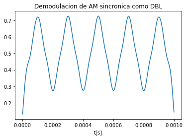

```python
###############################################
################# EJERCICIO 4 #################
###############################################

carrier=Ec*np.sin(2*np.pi*fc*t)
carrier2= Ec*np.cos(2*np.pi*fc*t)
exponencial=np.exp(2j*np.pi*fc*t)

m=0.5
msj=dsp.sawtooth(2*np.pi*fmsj*t,width=0.5)


def M_AM(msj,carrier,m):
    return ((1+m*msj)*carrier)

VAM=M_AM(msj,carrier,m)

def DEMOD_DBL(a,b,taps):
    c=a*b
    return np.abs(np.convolve(c,taps,'same'))   # probar la diferencia entre filtrar y no filtrar (para no filtrar se puede poner [1] como taps)
    #return np.abs(c)

Rx=DEMOD_DBL(VAM,carrier,taps)  # analizar que pasa cuando en vez de una exponencial ponemos un seno o un coseno

plt.plot(t,Rx)
plt.title("Demodulacion de AM sincronica como DBL")
plt.xlabel("t[s]")
```

# Va un precario derector de envolvente, que no sabe nada de la frecuencia de portadora ni de su fase

- Rectifica
- aplica pasabajos

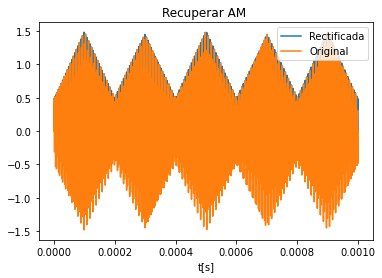

```python
VAM_rec=[]
for sample in range(len(VAM)):
#    print(sample)
    if VAM[sample]>0:
        VAM_rec.append(VAM[sample])
    else:
        VAM_rec.append(-VAM[sample])

plt.plot(t,VAM_rec,label="Rectificada")
plt.plot(t,VAM,label="Original")
plt.legend(loc='upper right')
plt.title("Recuperar AM ")
plt.xlabel("t[s]")
```

```python
FAM=np.abs(np.fft.fftshift(np.fft.fft(VAM_rec)))/N
plt.figure()
plt.plot(fcia,FAM)

taps=dsp.firwin(N,cutoff=20000,fs=fs)  # mi viejo viltro pasabajos de 20kHz
plt.figure()
envolvente=np.convolve(VAM_rec,taps,"same")
plt.figure()
plt.plot(t,VAM_rec)
plt.figure()
plt.plot(t,envolvente)
```

[output not shown]

[output not shown]

[output cut: 163 more lines]

[output not shown]

## EJERCICIO 5

- hacer una presentacion explicando las diferencias entre demodulacion sicronica y asincronica

## EJERCICIO 6

- hacer una funcion que reciba una señal modulada en AM, y los parametros que considere necesarios y retorne el indice de modulacion de la señal de AM.

# TRABAJO FINAL

- utilizando el generador de RF modular una señal en AM.
- capturar con el osciloscopio digital esta señal grabandola como .csv
- utilizando la funcion np.readcsv() obtener
  - indice de modulacion
  - señal de audio demodulada
  - espectro de la señal de audio demodulada
  - distorsion armonica de la señal de audio

```python
dato=[t,VAM]
dato=np.asarray(dato)
print(np.shape(dato))
dato=dato.T
print(np.shape(dato))
```

```
(2, 1000)
(1000, 2)
```

```python
dato
```

```
array([[ 0.00000000e+00,  0.00000000e+00],
       [ 1.00100100e-06,  4.84750110e-01],
       [ 2.00200200e-06, -3.07245527e-01],
       ...,
       [ 9.97997998e-04,  3.07245527e-01],
       [ 9.98998999e-04, -4.84750110e-01],
       [ 1.00000000e-03, -5.09502587e-14]])
```

```python
import csv
f = open('am.csv', 'w')

with f:

    writer = csv.writer(f)

    for row in dato:
        writer.writerow(row)
```

```python
data=np.genfromtxt('am.csv',delimiter=',')

t2=data[:,0]
ch1=data[:,1]
```

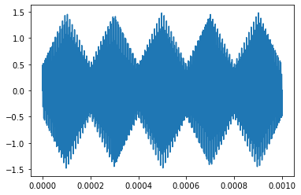

```python
plt.plot(t2,ch1)
```

```
El indice de modulacion generado es  0.5
El indice de modulacion calculado es  0.48
```

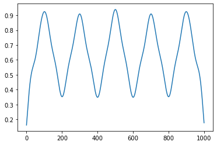

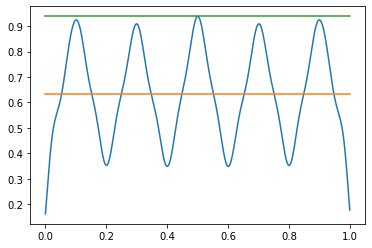

```python
######################################################
### implemento mi funcion detectora de envolvente ####
######################################################

def env_detec(VAM):
    VAM_rec=[]
    for sample in range(len(VAM)):
        if VAM[sample]>0:
            VAM_rec.append(VAM[sample])
        else:
            VAM_rec.append(-VAM[sample])
    taps=dsp.firwin(N,cutoff=20000,fs=fs)  # mi viejo viltro pasabajos de 20kHz
    envolvente=np.convolve(VAM_rec,taps,"same")
    return envolvente

audio=env_detec(ch1)
plt.plot(audio)

#######################################################
### implemento mi funcion calculo de indice de mod ####
#######################################################

print("El indice de modulacion generado es ",m)

def indicede_m(VAM):
    VAM_rec=[]
    for sample in range(len(VAM)):
        if VAM[sample]>0:
            VAM_rec.append(VAM[sample])
        else:
            VAM_rec.append(-VAM[sample])
    taps=dsp.firwin(N,cutoff=20000,fs=fs)  # mi viejo viltro pasabajos de 20kHz
    envolvente=np.convolve(VAM_rec,taps,"same")
    Ec=np.mean(envolvente)   # valor de portadora
    Em=np.max(envolvente)-Ec

    ejeEc=np.ones(len(envolvente))*Ec
    ejeEm=np.ones(len(envolvente))*np.max(envolvente)
    t=np.linspace(0,1,len(envolvente))
    plt.figure()
    plt.plot(t,envolvente,t,ejeEc,t,ejeEm)

    return round(Em/Ec,2)



m=indicede_m(ch1)
print("El indice de modulacion calculado es ",m)
```

```python
def THD_calc(audio,win="uniforme"):
    if win=="uniforme":
        win=np.ones(len(audio))
    elif win=="flattop":
        win=dsp.flattop(len(audio))
    elif win=="hann":
        win=dsp.hann(len(audio))
    audio=audio-np.mean(audio)    ### esto es como un acople de continua
    espec=np.abs(np.fft.fftshift(np.fft.fft(audio*win)))
    espec=espec[len(audio)//2:]
    f=np.argmax(espec)
    v0=espec[f]
    v1=espec[2*f]
    v2=espec[3*f]
    v3=espec[4*f]
    v4=espec[5*f]
    v5=espec[6*f]
    THD=round(((v1**2+v2**2+v3**2+v4**2+v5**2)/(v0**2))*100,2)
    return THD

THD=THD_calc(audio)
print ("La THD es ",THD,"%")
```

```
La THD es  1.78 %
```

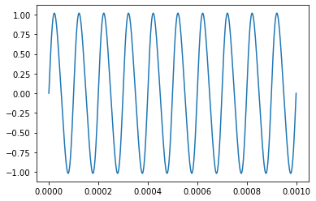

```python
t=np.linspace(0,1e-3,1000)
x=np.sin(2*np.pi*10000*t)+0.1*np.sin(2*np.pi*20000*t)
plt.plot(t,x)
```

```python
THD=THD_calc(x,win="flattop")
print ("La THD es ",THD,"%")
```

```
La THD es  1.0 %
```

jupyter nbconvert --to slides modulacion_lineal.ipynb --post serv